# Checking The Biases of the COMPAS System

Jeremy Hubinger

```r
# Import the data
# https://rdrr.io/cran/sjPlot/man/plot_grid.html
library(RCurl)
library(dplyr)
library(ggplot2)
compas <- read.csv('compas-scores-two-years.csv')

# Filter out unusable cases (inspired by ProPublica analysis)
compas <- compas %>%
    select(age, c_charge_degree, c_charge_desc, race, sex, priors_count, two_year_recid, days_b_screening_arrest, is_recid, decile_score, score_text) %>%
    filter(days_b_screening_arrest <= 30) %>%
    filter(days_b_screening_arrest >= -30) %>%
    filter(is_recid != -1) %>%
    filter(c_charge_degree != "O") %>%
    filter(score_text != 'N/A') %>%
    mutate(score_text = factor(score_text, levels = c("Low", "Medium", "High"))) %>%
    select(-c(days_b_screening_arrest, is_recid))

# And create some new variables (inspired by ProPublica)
compas <- compas %>%
    mutate(c_charge_degree = factor(c_charge_degree)) %>%
    mutate(race = factor(race)) %>%
    within(race <- relevel(race, ref = 3)) %>%
    mutate(sex = factor(sex, labels= c("Female","Male"))) %>%
    within(sex <- relevel(sex, ref = 2)) %>%
    mutate(score_factor = factor(score_text != "Low", labels = c("LowScore","HighScore"))) %>%
    mutate(race = case_when(
    race == "Asian" ~ "Other",
    race == "Native American" ~ "Other",
    race == "African-American" ~ "African-American",
    race == "Caucasian" ~ "Caucasian",
    race == "Other" ~ "Other",
    race == "Hispanic" ~ "Hispanic"
    ))
```

## Part 1: Introduction

This report will examine a tool (COMPAS or, Correctional Offender Management Profiling for Alternative Sanctions) from a company called Northpointe. This tool purports to be able to assign a score that can inform a court in determining the likelihood that an individual commits another crime after being released (recidivism). The data I will be using to examine this tool consists of seven thousand data points, trimmed down to include only those that we have full data about, leaving us with a little over six thousand points. Each data point represents a person who went through the court system and was given a score. Along with the score the algorithm gave, we also have a myriad of other data about who that person was, including whether they did in fact commit another crime within the two years after release. It is important to note that our data comes from one county in Florida, Broward County.

Here is a sample of the data:

```r
head(compas)
```

```
##   age c_charge_degree                  c_charge_desc             race  sex
## 1  69               F   Aggravated Assault w/Firearm            Other Male
## 2  34               F Felony Battery w/Prior Convict African-American Male
## 3  24               F          Possession of Cocaine African-American Male
## 4  44               M                        Battery            Other Male
## 5  41               F      Possession Burglary Tools        Caucasian Male
## 6  43               F          arrest case no charge            Other Male
##   priors_count two_year_recid decile_score score_text score_factor
## 1            0              0            1        Low     LowScore
## 2            0              1            3        Low     LowScore
## 3            4              1            4        Low     LowScore
## 4            0              0            1        Low     LowScore
## 5           14              1            6     Medium    HighScore
## 6            3              0            4        Low     LowScore
```

In my analysis I will first attempt to determine what factors go into determining a score given out by the COMPAS system. After determining what these factors are, I will then look at whether or not it makes sense for them to look at these factors. That is, do the variables that COMPAS takes into account when assigning scores actually correlate with recidivism, or are there undue biases in their system.

## Part 2: Analysis

For the first part of my analysis I want to determine what factors are taken into account when calculating a score given by the COMPAS tool. For this, we will look at the “decile_score” column of the data, which gives the score that the COMPAS tool gave out to the person on a scale from 1-10. In order to understand this score better, we should first understand the distribution of scores. This can be done with a histogram:

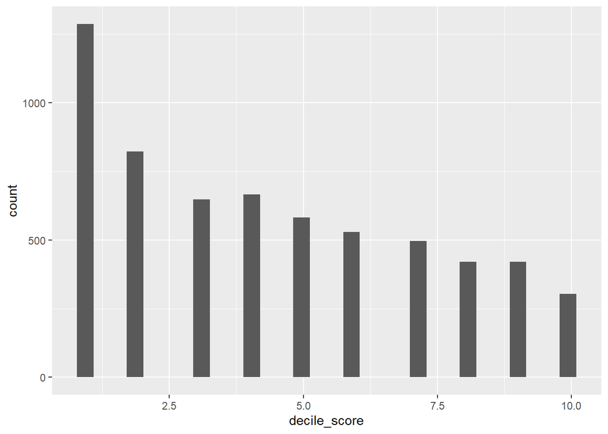

```r
ggplot(compas, aes(x=decile_score)) +
  geom_histogram()
```

Next, we will try to determine what factors go into determining this score. To do this I will use linear regression to model decile_score by the degree of someone’s charge (felony or misdemeanor), their sex, race, age, and number of priors. The model summary is as follows:

```r
model_1 <- lm(data=compas, decile_score ~ c_charge_degree + sex + race + priors_count + age)
summary(model_1)
```

```
##
## Call:
## lm(formula = decile_score ~ c_charge_degree + sex + race + priors_count +
##     age, data = compas)
##
## Residuals:
##     Min      1Q  Median      3Q     Max
## -6.4012 -1.5944 -0.2863  1.3874  7.5874
##
## Coefficients:
##                   Estimate Std. Error t value Pr(>|t|)
## (Intercept)       7.640301   0.088110  86.713  < 2e-16 ***
## c_charge_degreeM -0.458669   0.057734  -7.945  2.3e-15 ***
## sexFemale         0.032838   0.069716   0.471    0.638
## raceCaucasian    -0.530989   0.062618  -8.480  < 2e-16 ***
## raceHispanic     -0.978481   0.102867  -9.512  < 2e-16 ***
## raceOther        -1.313719   0.116117 -11.314  < 2e-16 ***
## priors_count      0.275622   0.006029  45.714  < 2e-16 ***
## age              -0.104696   0.002403 -43.578  < 2e-16 ***
## ---
## Signif. codes:  0 '***' 0.001 '**' 0.01 '*' 0.05 '.' 0.1 ' ' 1
##
## Residual standard error: 2.129 on 6164 degrees of freedom
## Multiple R-squared:  0.4386, Adjusted R-squared:  0.4379
## F-statistic: 687.8 on 7 and 6164 DF,  p-value: < 2.2e-16
```

There are a few things that we can gather from the model summary table. The coefficients for charge_degree (whether the person committed a misdemeanor or a felony), and race are all fairly small, varying from 0.4 to 1.3 in magnitude. These numbers on their own aren’t super significant, however we have to look at the broader picture. Because the P values of these predictors are so low, they are almost certainly taken into account when determining a person’s score. Later, we will look at whether this is necessary for providing an accurate prediction of recidivism.

Since the P value for sex is so large, the COMPAS system almost certainly does not take this into account.

Finally we can look at the last two predictors in the model, age and number of priors. Since these two predictors are quantitative, we have to first understand the distribution of these numbers in our data to understand the coefficients well. The histograms for age and number of priors are as follows:

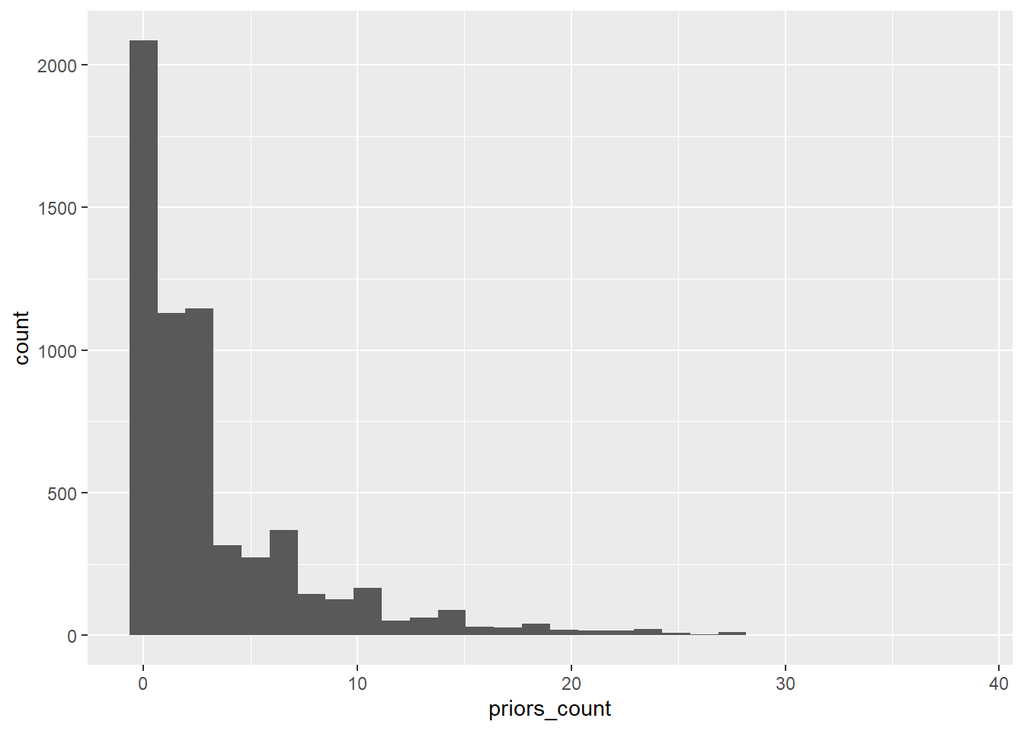

```r
ggplot(compas, aes(x=priors_count)) +
  geom_histogram()
```

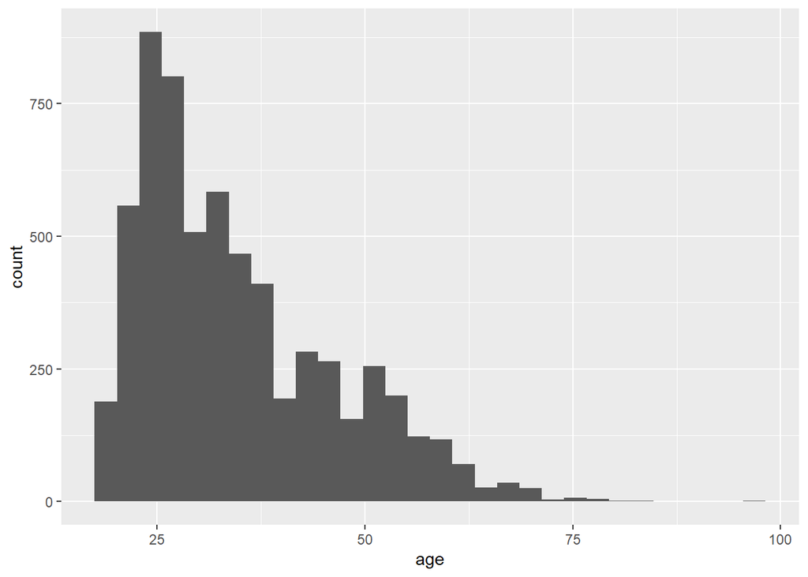

```r
ggplot(compas, aes(x=age)) +
  geom_histogram()
```

The coefficient for age was -0.1 meaning that for every year older you are, your score tends to drop by 0.1 (controlling for all the other factors in the model.) That means that compared to a 25 year old, a 50 year old will tend to have a score that is 2.5 points lower. This is a quite significant change, and seems to imply that the COMPAS system takes age as one of its main factors in determining score. This is backed up by the very low P value in the model table.

We can see a similar story for the number of priors someone has. Looking at the coefficient of 0.27, someone with 2 priors will have an increase of only about half a point, but someone with 10 priors, will have their score increased by over two and half points. For the majority of people, since their number of priors is so low (see the histogram above), this is not going to have a significant effect on their score, but for the very few who have a large number of priors, this will have a very significant effect. Again, looking at the very low P value we can see that their system certainly takes the number of priors someone has into account when determining score.

Next, we will look at whether or not the COMPAS system is justified in using the predictors it does. That is, are the predictors we just determined it uses, actually good predictors of recidivism. It is important to note the overall rate of recidivism in the data is 45%, meaning that a model that was guessing would be accurate 55% of the time.

```r
sum(compas[, "two_year_recid"])/nrow(compas)
```

```
## [1] 0.4551199
```

With that in mind, we can start making our own models of recidivism using different sets of predictors. If we trained our model on the same data we evaluated it on, that would produce results that were almost certainly better than the COMPAS system, because they did not have that advantage. To avoid this, the data will be split, some will be used for training and some for evaluation. We will do this process one hundred times for each model, and then average the accuracy of the different tests.

The accuracies of the different models I created are reported below:

```r
# Load the package
library(caret)
library(e1071)
# Set the seed
set.seed(155)
# Run the algorithm
my_model <- train(
  as.factor(two_year_recid) ~ age + priors_count + race + c_charge_degree + sex,
  data = compas,
  method = "glm",
  trControl = trainControl(method = "cv", number = 100),
  na.action = na.omit
)
# Get evaluation metrics (averaged across the folds)
my_model$results
```

two_year_recid ~ age : 0.581

two_year_recid ~ race : 0.568

two_year_recid ~ sex : 0.544

two_year_recid ~ priors_count : 0.635

two_year_recid ~ c_charge_degree : 0.522

two_year_recid ~ priors_count + age : 0.679

two_year_recid ~ priors_count + age + c_charge_degree + race + sex : 0.676

These results are interesting for many reasons. The first thing that should be noted is that the standard deviation of most of the averages was around 0.05, this is important to keep in mind when comparing the accuracy. The first conclusion that we can make is that charge_degree, race, and sex alone are practically as good as guessing at random. There were only two predictors that had any real significant effect on the accuracy of the model, and those were age and number of priors. This is backed up by the fact that the accuracy of the model with both of those predictors was just as high as the model with every predictor. We can visualize this fact with the graph of the model with every predictor:

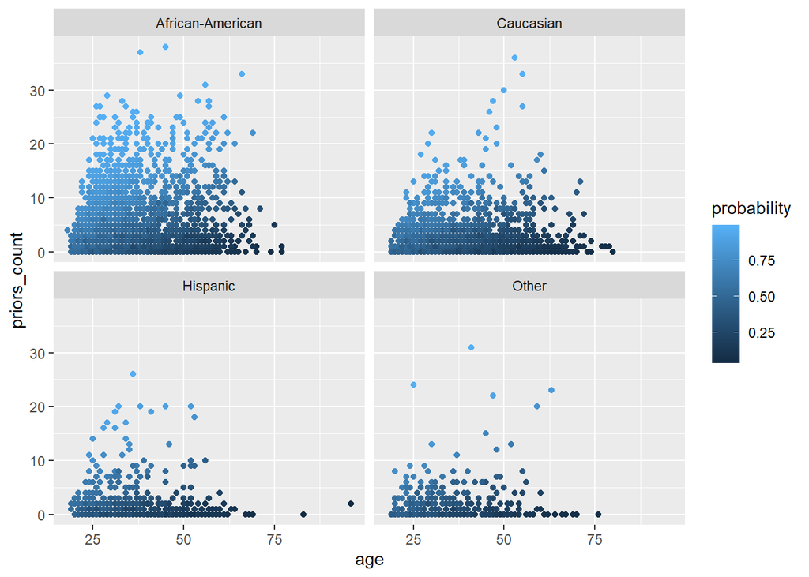

```r
model_2 <- glm(data=compas, as.factor(two_year_recid) ~ age + priors_count + c_charge_degree + sex + race, family = "binomial")
compas_predictions <- compas %>%
  mutate(probability = model_2$fitted.values) %>%
  mutate(odds = probability / (1-probability)) %>%
  mutate(log_odds = log(odds))

ggplot(compas_predictions, aes(x = age, y = priors_count, color = probability)) +
  geom_point() +
  facet_wrap(~race)
```

Notice how in this graph the x and y axis (age and priors_count, respectively) seem to determine the probability (the equivalent of decile_score, except for my model), in other words, the color transitions smoothly. This means that the other predictors (race, sex, charge dregree) don’t have an effect on a person’s score.

This seems to imply that the only factors that the COMPAS system should take into account are age and priors. However, that is not what we saw in the first part of our analysis. We saw that the COMPAS system actually takes into account race and charge_degree. This can be visualized by looking at the same graph we looked at above, except this time the color will be determined by decile_score.

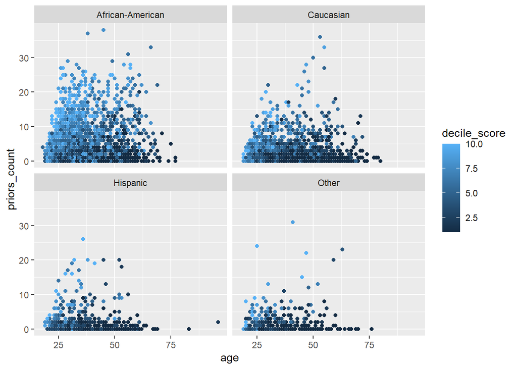

```r
ggplot(compas, aes(y=priors_count, x=age, color = decile_score)) +
  geom_point() +
  facet_wrap(~race)
```

Notice how the color does not transition smoothly, but that there are wild jumps in decile score, meaning that their model takes into account factors other than age and priors_count, something that our analysis would say was unnecessary, and in fact leads to even more error. This is backed up by the fact that the accuracy of their model in predicting recidivism was 0.664, a score that was slightly lower (although still within one or two standard deviations) than the model that takes into account just age and priors.

This implies that there is some undue bias in the COMPAS tool. Our analysis does not conclude what affect this bias has on the results of decile_score. That is, is it underestimated, overestimated, different for different people? These question would require a deeper analysis (the Propublica report goes into more detail about this.) Our report can only conclude that there is some undue bias in the magnitude of the score given out by the COMPAS system.